# Bridging the Gap: Exploring a Middle-Way Approach for Prosodic Annotation

Aleksandra Ćwiek, Alina Gregori, Paula G. Sánchez-Ramón, Frank Kügler, Pilar Prieto

2023-09-04

# 1 Introduction

Prosodic annotation plays a critical role in linguistic research, enabling a detailed exploration of communication subtleties in diverse languages and contexts. Various methods for prosodic annotation exist, with some well-known and accepted, such as ToBI (Silverman et al. 1992). However, prosody research encounters challenges in the manual annotation of data, primarily regarding inter-rater reliability, where multiple annotators’ agreement varies significantly (even between 60% and 90%, Breen, et al. 2012), leading to potential errors and manipulation.

Manual annotation remains time-consuming and labor-intensive, resulting in limited data availability, hindering the development of reliable computational models for comprehensive and robust prosodic annotation across various schemes and languages (see Ananthakrishnan and Narayanan 2008; Rosenberg 2010 as examples for ToBI on Standard American English). To tackle this challenge, our project aims to adopt a middle-way approach, harnessing the expertise of skilled annotators alongside the power of computational tools while being cautious of potential challenges such as the complexity of prosody, interpretation of results, and ethical considerations regarding biases in training data and social impacts. By establishing robust computational models, we seek to significantly speed up the annotation process, generalize findings to new linguistic data, and pave the way for more extensive cross-linguistic studies in prosodic research.

In our project, we aim to establish connections between prosodic prominence marking and automatic predictions of focus conditions – focus representing a pragmatic domain of prominence (cf. e.g., Krifka 2008). To achieve this, we will analyze data from German and Catalan speakers producing focus types as degrees of prominence in a semi-controlled environment. The perceived prominence of focus types in these data was annotated on a scale from 0 to 3 for prosodic prominence (DIMA, Kügler et al. 2015; Kügler et al. 2019; Kügler, Baumann, and Röhr 2022). German and Catalan are suitable languages for investigating the applicability of computational systems across different languages, given their distinct prosodic prominence marking in terms of rhythm class and accentuation patterns (cf. Krahmer and Swerts 2007 for Germanic and Romance languages; Cole et al. 2019 for differences between Spanish, French, and English).

To capture acoustic markers of prominence, such as F0 (max peak, mean, range), intensity (max peak, mean, range), and duration, we will extract these measures from the accented syllables of focused words. These acoustic markers will serve as predictors in a Bayesian ordinal model to rate prominence. Our models will account for language-specific variations in acoustic features of prominence between Catalan and German.

Our goal is to identify the most predictive features of prominence in prosody for German and Catalan, effectively bridging the gap between manual and computer-aided annotation. By establishing these links, we aim to address the challenges posed by tiresome manual annotation. Subsequently, we plan to employ our findings to build a classifier for automatic focus-type assignment to utterances, which will undergo verification by human annotators.

# 2 Data preparation

## 2.1 Source setup

```r
########## folders ##########
# current folder (first go to session -> set working directory -> to source file location)
parentfolder <- dirname(getwd())

data          <- paste0(parentfolder, '/MultIS_data/')
audiodata     <- paste0(parentfolder, '/audio_processed/')
dataworkspace <- paste0(parentfolder, '/data_processed/')
datamerged    <- paste0(parentfolder, '/data_merged/')
models        <- paste0(parentfolder, '/models/')
plots         <- paste0(parentfolder, '/plots/')
scripts       <- paste0(parentfolder, '/scripts/')

########## source file ##########

#source(paste0(scripts, "adjectives-preparation.R"))

#################### packages ####################

# audiovisual processing
library(seewave) # this for signal processing
library(signal)
library(rPraat)
library(dplR)
library(signal)
library(rstudioapi)
library(stringr)
library(wrassp)
library(readr)
library(readxl)
library(readtextgrid)   #reading txt grids
library(textgRid)
library(zoo)
library(pracma)
#library(stringi) # for syllable replacement
library(tuneR)

# data manipulation and viz
library(tidyverse)
library(ggpubr)
library(gridExtra)
colorBlindBlack8  <- c("#000000", "#E69F00", "#56B4E9", "#009E73",
                       "#F0E442", "#0072B2", "#D55E00", "#CC79A7")

# modeling
library(broom) # for tidy model outputs
library(brms)
library(cmdstanr)
library(HDInterval) # package for credible interval computation
library(tidybayes) # plotting
library(bayesplot)
# option for Bayesian regression models:
# use all available cores for parallel computing
options(mc.cores = parallel::detectCores())

# Bayes factor
#library(BayesFactor)
library(bayestestR)

# Diagnostics GUI
library(shinystan)
```

```r
participant_info <- read_delim(paste0(data,"ParticipantInfoFocProd.csv"), delim = "\t")
```

# 3 Processing the audio

Here, we show the process of handling the audio data from the raw audio, incl. annotation.

## 3.1 Select & save parts

The files provided are long. For our sake, we just need parts from which we will extract information, so we will first chop the files accordingly to our needs.

Because the original annotation is done in ELAN, we have to prepare the files for processing.

- Export .eaf to .TextGrid
- Open .TextGrid in Praat
- Save .TextGrid using Praat

Now, the files can be imported. If this step is skipped, the files will not be imported correctly.

Item codes:

- G04 —> number of participant per language (G = German, C = Catalan)
- P —> practice trial or target item (P = Practice, T = Target)
- 01 —> Itemnumber (begins from 01 for both practice and target)
- I —> focus condition (I = Information focus, C = Contrastive focus, R = Corrective focus, B = Background, F = filler item)

We will first locate the .wav files in the input location.

```r
wavFiles <- list.files(data, pattern = "\\.wav$", full.names = TRUE)

# This is the tier we will be cutting from
targetTier <- "Label"
```

Now we loop through .wav files.

```r
for (wavFile in wavFiles) {

  # Generate the corresponding TextGrid file name
  textGridFile <- sub("\\.wav$", ".TextGrid", wavFile)

  # Check if the TextGrid file exists
  if (file.exists(textGridFile)) {

    # Read the TextGrid file
    tg <- readtextgrid::read_textgrid(textGridFile)

    # Get the tier specified as input
    tier <- tg[tg$tier_name == targetTier, ]

    # Loop through intervals and save corresponding parts of the .wav file
    for (i in 1:nrow(tier)) {
      interval <- tier[i, ]

      # Look if string is text begins with C or G that is followed by a digit
      if (str_detect(interval$text, "^(C|G)\\d")) {
        startTime <- interval$xmin
        endTime <- interval$xmax

        # Define the output file name
        outputFile <- paste0(audiodata, interval$text, ".wav")

        # Check if the file already exists
        if (!file.exists(outputFile)) {
          # Read the .wav file
          audio <- readWave(wavFile, from = startTime, to = endTime, units = "seconds")

          # Convert stereo to mono
          audio <- mono(audio)

          # Write the .wav file
          writeWave(audio, file = outputFile)

          # Remove unnecessary variables from memory
          rm(audio)
        } else {
          cat("File", outputFile, "already exists. Skipping.\n")
        }

        # Remove unnecessary variables from memory
        rm(startTime, endTime, outputFile)
      }
    }

    # Remove the TextGrid object from memory
    rm(tg)
  }
}
```

```
## File C:/Users/cwiek/OneDrive/Projects/MultIS-Collaboration/Analysis/audio_processed/C02_T_01_F.wav already exists. Skipping.
## File C:/Users/cwiek/OneDrive/Projects/MultIS-Collaboration/Analysis/audio_processed/C02_T_02_I.wav already exists. Skipping.
## File C:/Users/cwiek/OneDrive/Projects/MultIS-Collaboration/Analysis/audio_processed/C02_T_03_I.wav already exists. Skipping.
## File C:/Users/cwiek/OneDrive/Projects/MultIS-Collaboration/Analysis/audio_processed/C02_T_04_C.wav already exists. Skipping.
## File C:/Users/cwiek/OneDrive/Projects/MultIS-Collaboration/Analysis/audio_processed/C02_T_05_R.wav already exists. Skipping.
## File C:/Users/cwiek/OneDrive/Projects/MultIS-Collaboration/Analysis/audio_processed/C02_T_06_F.wav already exists. Skipping.
## File C:/Users/cwiek/OneDrive/Projects/MultIS-Collaboration/Analysis/audio_processed/C02_T_07_I.wav already exists. Skipping.
## File C:/Users/cwiek/OneDrive/Projects/MultIS-Collaboration/Analysis/audio_processed/C02_T_08_C.wav already exists. Skipping.
## File C:/Users/cwiek/OneDrive/Projects/MultIS-Collaboration/Analysis/audio_processed/C02_T_09_R.wav already exists. Skipping.
## File C:/Users/cwiek/OneDrive/Projects/MultIS-Collaboration/Analysis/audio_processed/C02_T_10_F.wav already exists. Skipping.
## File C:/Users/cwiek/OneDrive/Projects/MultIS-Collaboration/Analysis/audio_processed/C02_T_11_C.wav already exists. Skipping.
## File C:/Users/cwiek/OneDrive/Projects/MultIS-Collaboration/Analysis/audio_processed/C02_T_12_R.wav already exists. Skipping.
## File C:/Users/cwiek/OneDrive/Projects/MultIS-Collaboration/Analysis/audio_processed/C02_T_13_I.wav already exists. Skipping.
## File C:/Users/cwiek/OneDrive/Projects/MultIS-Collaboration/Analysis/audio_processed/C02_T_14_F.wav already exists. Skipping.
## File C:/Users/cwiek/OneDrive/Projects/MultIS-Collaboration/Analysis/audio_processed/C02_T_15_C.wav already exists. Skipping.
## File C:/Users/cwiek/OneDrive/Projects/MultIS-Collaboration/Analysis/audio_processed/C02_T_16_R.wav already exists. Skipping.
## File C:/Users/cwiek/OneDrive/Projects/MultIS-Collaboration/Analysis/audio_processed/C02_T_17_I.wav already exists. Skipping.
## File C:/Users/cwiek/OneDrive/Projects/MultIS-Collaboration/Analysis/audio_processed/C02_T_18_C.wav already exists. Skipping.
## File C:/Users/cwiek/OneDrive/Projects/MultIS-Collaboration/Analysis/audio_processed/C02_T_19_R.wav already exists. Skipping.
## File C:/Users/cwiek/OneDrive/Projects/MultIS-Collaboration/Analysis/audio_processed/C02_T_20_F.wav already exists. Skipping.
## File C:/Users/cwiek/OneDrive/Projects/MultIS-Collaboration/Analysis/audio_processed/C02_T_21_C.wav already exists. Skipping.
## File C:/Users/cwiek/OneDrive/Projects/MultIS-Collaboration/Analysis/audio_processed/C02_T_22_R.wav already exists. Skipping.
## File C:/Users/cwiek/OneDrive/Projects/MultIS-Collaboration/Analysis/audio_processed/C02_T_23_I.wav already exists. Skipping.
## File C:/Users/cwiek/OneDrive/Projects/MultIS-Collaboration/Analysis/audio_processed/C02_T_25_C.wav already exists. Skipping.
## File C:/Users/cwiek/OneDrive/Projects/MultIS-Collaboration/Analysis/audio_processed/C02_T_26_R.wav already exists. Skipping.
## File C:/Users/cwiek/OneDrive/Projects/MultIS-Collaboration/Analysis/audio_processed/C02_T_27_I.wav already exists. Skipping.
## File C:/Users/cwiek/OneDrive/Projects/MultIS-Collaboration/Analysis/audio_processed/C02_T_28_F.wav already exists. Skipping.
## File C:/Users/cwiek/OneDrive/Projects/MultIS-Collaboration/Analysis/audio_processed/C02_T_29_B.wav already exists. Skipping.
## File C:/Users/cwiek/OneDrive/Projects/MultIS-Collaboration/Analysis/audio_processed/C02_T_30_B.wav already exists. Skipping.
## File C:/Users/cwiek/OneDrive/Projects/MultIS-Collaboration/Analysis/audio_processed/C02_T_31_B.wav already exists. Skipping.
## File C:/Users/cwiek/OneDrive/Projects/MultIS-Collaboration/Analysis/audio_processed/C02_T_32_B.wav already exists. Skipping.
## File C:/Users/cwiek/OneDrive/Projects/MultIS-Collaboration/Analysis/audio_processed/C02_T_33_B.wav already exists. Skipping.
## File C:/Users/cwiek/OneDrive/Projects/MultIS-Collaboration/Analysis/audio_processed/C02_T_34_B.wav already exists. Skipping.
## File C:/Users/cwiek/OneDrive/Projects/MultIS-Collaboration/Analysis/audio_processed/C02_T_35_B.wav already exists. Skipping.
## File C:/Users/cwiek/OneDrive/Projects/MultIS-Collaboration/Analysis/audio_processed/G01_P_01_I.wav already exists. Skipping.
## File C:/Users/cwiek/OneDrive/Projects/MultIS-Collaboration/Analysis/audio_processed/G01_P_02_F.wav already exists. Skipping.
## File C:/Users/cwiek/OneDrive/Projects/MultIS-Collaboration/Analysis/audio_processed/G01_P_07_B.wav already exists. Skipping.
## File C:/Users/cwiek/OneDrive/Projects/MultIS-Collaboration/Analysis/audio_processed/G01_P_03_I.wav already exists. Skipping.
## File C:/Users/cwiek/OneDrive/Projects/MultIS-Collaboration/Analysis/audio_processed/G01_P_04_F.wav already exists. Skipping.
## File C:/Users/cwiek/OneDrive/Projects/MultIS-Collaboration/Analysis/audio_processed/G01_P_08_B.wav already exists. Skipping.
```

[output cut: 64 more lines]

```
## File C:/Users/cwiek/OneDrive/Projects/MultIS-Collaboration/Analysis/audio_processed/G04_T_23_I.wav already exists. Skipping.
## File C:/Users/cwiek/OneDrive/Projects/MultIS-Collaboration/Analysis/audio_processed/G04_T_24_F.wav already exists. Skipping.
## File C:/Users/cwiek/OneDrive/Projects/MultIS-Collaboration/Analysis/audio_processed/G04_T_25_C.wav already exists. Skipping.
## File C:/Users/cwiek/OneDrive/Projects/MultIS-Collaboration/Analysis/audio_processed/G04_T_26_R.wav already exists. Skipping.
## File C:/Users/cwiek/OneDrive/Projects/MultIS-Collaboration/Analysis/audio_processed/G04_T_27_I.wav already exists. Skipping.
## File C:/Users/cwiek/OneDrive/Projects/MultIS-Collaboration/Analysis/audio_processed/G04_T_28_F.wav already exists. Skipping.
## File C:/Users/cwiek/OneDrive/Projects/MultIS-Collaboration/Analysis/audio_processed/G04_P_07_B.wav already exists. Skipping.
## File C:/Users/cwiek/OneDrive/Projects/MultIS-Collaboration/Analysis/audio_processed/G04_P_08_B.wav already exists. Skipping.
## File C:/Users/cwiek/OneDrive/Projects/MultIS-Collaboration/Analysis/audio_processed/G04_T_29_B.wav already exists. Skipping.
## File C:/Users/cwiek/OneDrive/Projects/MultIS-Collaboration/Analysis/audio_processed/G04_T_30_B.wav already exists. Skipping.
## File C:/Users/cwiek/OneDrive/Projects/MultIS-Collaboration/Analysis/audio_processed/G04_T_31_B.wav already exists. Skipping.
## File C:/Users/cwiek/OneDrive/Projects/MultIS-Collaboration/Analysis/audio_processed/G04_T_32B.wav already exists. Skipping.
## File C:/Users/cwiek/OneDrive/Projects/MultIS-Collaboration/Analysis/audio_processed/G04_T_33_B.wav already exists. Skipping.
## File C:/Users/cwiek/OneDrive/Projects/MultIS-Collaboration/Analysis/audio_processed/G04_T_34_B.wav already exists. Skipping.
## File C:/Users/cwiek/OneDrive/Projects/MultIS-Collaboration/Analysis/audio_processed/G04_T_35_B.wav already exists. Skipping.
```

But we also need the TextGrids for feature extraction in the stressed syllables.

First, we create a custom function to writeTextGrid in a format that is both Praat and other functions-readable.

```r
writeTextGrid <- function(data, outputFile) {
  # Open a connection to the output file
  con <- file(outputFile, "w")

  # Write the TextGrid header
  cat('File type = "ooTextFile"\n', file = con)
  cat('Object class = "TextGrid"\n', file = con)
  cat('\n', file = con)  # Add an extra line
  cat('xmin = 0 \n', file = con)
  cat('xmax =', max(data$xmax), '\n', file = con)
  cat('tiers? <exists> \n', file = con)
  cat('size =', n_distinct(data$tier_name), '\n', file = con)
  cat('item []:', '\n', file = con)
  # Write the tier information
  tiers <- unique(data[, c("tier_num", "tier_name", "tier_type")])
  for (i in 1:nrow(tiers)) {
    cat(paste0('    item [', i, ']:\n'), file = con)
    cat(paste0('        class = "', tiers$tier_type[i], '"\n'), file = con)
    cat(paste0('        name = "', tiers$tier_name[i], '"\n'), file = con)
    cat(paste0('        xmin = 0\n'), file = con)
    cat(paste0('        xmax = ', max(data$xmax), '\n'), file = con)
    # Write intervals or points
    if (tiers$tier_type[i] == "IntervalTier") {
      intervals <- data[data$tier_name == tiers$tier_name[i], ]
      cat(paste0('        intervals: size = ', nrow(intervals), '\n'), file = con)
      for (j in 1:nrow(intervals)) {
        cat(paste0('        intervals [', j, ']:\n'), file = con)
        cat(paste0('            xmin = ', intervals$xmin[j], '\n'), file = con)
        cat(paste0('            xmax = ', intervals$xmax[j], '\n'), file = con)
        cat(paste0('            text = "', intervals$text[j], '"\n'), file = con)
      }
    } else if (tiers$tier_type[i] == "PointTier") {
      points <- data[data$tier_name == tiers$tier_name[i], ]
      cat(paste0('        points: size = ', nrow(points), '\n'), file = con)
      for (j in 1:nrow(points)) {
        cat(paste0('        points [', j, ']:\n'), file = con)
        cat(paste0('            number = ', j - 1, '\n'), file = con)  # Point numbers start from 0
        cat(paste0('            time = ', points$xmax[j], '\n'), file = con)  # Assuming xmax as time
        cat(paste0('            mark = "', points$text[j], '"\n'), file = con)
      }
    }
  }

  # Close the connection
  close(con)
}
```

Now, we loop through the same list of files that we used for .wav extraction and extract the excerpts of TextGrids for the .wavs.

```r
# Loop through WAV files
for (wavFile in wavFiles) {

  # Generate the corresponding TextGrid file name
  textGridFile <- sub("\\.wav$", ".TextGrid", wavFile)

  # Check if the TextGrid file exists
  if (file.exists(textGridFile)) {

    # Read the original TextGrid file
    originalTg <- readtextgrid::read_textgrid(textGridFile)

    # Get the tier specified as input
    tier <- originalTg[originalTg$tier_name == targetTier, ]

    # Loop through intervals and annotations and add them to the new TextGrid
    for (i in 1:nrow(tier)) {
      interval <- tier[i, ]

      # Check if interval$text starts with "G" or "C"
      if (str_detect(interval$text, "^(C|G)\\d")) {
        startTime <- interval$xmin
        endTime <- interval$xmax

        # Check if the new TextGrid file already exists
        newTgFile <- file.path(paste0(audiodata, interval$text, ".TextGrid"))

        if (!file.exists(newTgFile)) {
          # Find the corresponding annotations in the original TextGrid
          originalAnnotations <- originalTg[originalTg$xmin >= startTime & originalTg$xmax <= endTime, ]

          # Ensure that all tiers from originalTg are present in newTgData
          missingTiers <- setdiff(unique(originalTg$tier_name), unique(originalAnnotations$tier_name))

          # Initialize newTgData as an empty data frame
          newTgData <- data.frame()

          for (tier_name in missingTiers) {
            # Find corresponding intervals in the original TextGrid for missing tiers
            originalIntervals <- originalTg[originalTg$tier_name == tier_name, ]

            # Add missing tiers to newTgData with adjusted time
            newTgData <- rbind(newTgData, mutate(originalIntervals,
                                                 xmin = xmin - startTime,
                                                 xmax = xmax - startTime))

            # Filter rows where xmin is smaller than or equal to zero
            newTgData <- newTgData %>% filter(xmin <= 0)

            # Keep only the row with the largest xmin value if there are multiple rows
            newTgData <- newTgData %>%
              group_by(tier_name) %>%
              filter(xmin == max(xmin)) %>%
              ungroup()
          }

          # Time normalization missing tiers
          newTgData$xmin <- 0
          newTgData$xmax <- max(originalAnnotations$xmax) - startTime

          # Copy annotations from originalAnnotations
          newTgData <- rbind(newTgData, mutate(originalAnnotations,
                                               xmin = xmin - startTime,
                                               xmax = xmax - startTime))

          # Time normalization global
          newTgData$tier_xmin <- 0
          newTgData$tier_xmax <- max(originalAnnotations$xmax) - startTime

          # Sort by tier_num
          newTgData <- newTgData %>% arrange(tier_num, xmin)

          # Check if there is data to write
          if (nrow(newTgData) > 0) {
            # Save the new TextGrid data as a TextGrid file
            writeTextGrid(newTgData, newTgFile)
          }
        }
      }
    }
  }
}

# Remove unnecessary variables from memory
rm(interval, startTime, endTime, newTgFile, originalAnnotations, originalIntervals, missingTiers, newTgData, tier, wavFile, wavFiles)
rm(originalTg)
rm(targetTier)
```

## 3.2 Temporary: Metadata

```r
# List of the WAV files
list_wavs <- list.files(audiodata, pattern = ".wav")

# Function to map focus characters to focus values
mapFocus <- function(char) {
  switch(char,
         I = "information",
         C = "contrastive",
         R = "corrective",
         B = "background",
         F = "filler",
         "unknown")
}

# Initialize an empty dataframe to store the metadata
META <- data.frame(File = character(),
                   Language = character(),
                   Participant = numeric(),
                   Item_type = character(),
                   Item_num = numeric(),
                   Focus = character(),
                   stringsAsFactors = FALSE)

# Loop through the WAV file names and decode the information
for (wavFile in list_wavs) {
  # Split the file name using "_"
  parts <- strsplit(wavFile, "_")[[1]]

  # Extract the relevant parts
  File <- sub("\\.wav$", "", wavFile)
  Language <- if (startsWith(parts[1], "G")) "German" else "Catalan"
  Participant <- as.numeric(parse_number(parts[1]))
  Item_type <- if (parts[2] == "P") "practice" else "target"
  Item_num <- as.numeric(parts[3])
  Focus <- mapFocus(substr(parts[4], 1, 1))  # Extract the first character

  # Create a data frame for the current file
  file_meta <- data.frame(File, Language, Participant, Item_type, Item_num, Focus)

  # Append the file metadata to META
  META <- rbind(META, file_meta)

  # Remove unnecessary variables from memory
  rm(parts, File, Language, Participant, Item_type, Item_num, Focus, file_meta)
}
```

```r
# Process participant_info so that participant number column is only number
participant_info$Participant <- parse_number(participant_info$Participant)

# Merge the dataframes by "Participant" and "Language"
META <- merge(META, participant_info, by = c("Participant", "Language"), all.x = TRUE)
```

## 3.3 Processing audio into time series

Having cut the parts out, we now want to loop through those parts in strategic places and extract acoustic measures.

Ideally, we also want to analyze, how acoustics and gesture work together, so we will adapt our higher-sampled audio to match the video. The video was recorded in **25 frames/second**, therefore we have to downsample radically.

This part is copied from FLESH original project_Rhyme.

### 3.3.1 Amplitude envelope extraction

This part was taken from the [Envision Bootcamp](https://wimpouw.github.io/EnvisionBootcamp2021/extract_AmplitudeEnvelope_Rmarkdown.html) and cleaned for clarity.

```r
# Set whether to overwrite existing files
overwrite <- FALSE

# List of the WAV files
list_wavs <- list.files(audiodata, pattern = ".wav")

# Processing settings
resample_rate <- 100 # Hz
smoothing <- 5 # 5Hz low-pass Hanning (the lower the value, the smoother)

##################### Main function to extract smoothed envelope ###############################

amplitude_envelope.extract <- function(locationsound, smoothingHz, resampledHz) {
  # Read the sound file into R
  snd <- rPraat::snd.read(locationsound)

  # Apply the Hilbert transform to the signal
  hilb <- seewave::hilbert(snd$sig, f = snd$fs, fftw = FALSE)

  # Apply complex modulus
  env <- as.vector(abs(hilb))

  # Smooth with a Hanning window
  env_smoothed <- dplR::hanning(x = env, n = snd$fs / smoothingHz)

  # Set undeterminable values at the beginning and end to NA and then to 0
  env_smoothed[is.na(env_smoothed)] <- 0

  # Resample settings at the desired sampling rate
  f <- approxfun(1:(snd$duration * snd$fs), env_smoothed)

  # Resample
  downsampled <- f(seq(from = 0, to = snd$duration * snd$fs, by = snd$fs / resampledHz))

  # Return the downsampled smoothed amplitude envelope
  return(downsampled[!is.na(downsampled)])
}

# Loop through soundfile locations
for (wav in list_wavs) {
  # Do not run this when these files are already generated and overwrite is not set to TRUE
  if ((!file.exists(paste0(dataworkspace, substr(wav, 1, nchar(wav) - 4), "_ENV", ".csv"))) & (overwrite != TRUE)) {
    # Location of the current sound file in the loop
    locsound <- paste0(audiodata, wav)

    # Get the amplitude envelope at location, 5Hz Hanning, 100Hz sampling
    env <- amplitude_envelope.extract(locsound, smoothing, resample_rate)

    # Make a time vector based on the sampling rate (1000/Hz)
    time_ms <- seq(1000 / resample_rate, length(env) * (1000 / resample_rate), by = 1000 / resample_rate)

    # Bind into a data frame
    ENV <- cbind.data.frame(time_ms, env)

    # Save it to a folder
    write.csv(ENV, file = paste0(dataworkspace, substr(wav, 1, nchar(wav) - 4), "_ENV", ".csv"), row.names = FALSE)

    # Remove unnecessary variables from memory
    rm(env, time_ms, ENV)
  }
}
```

### 3.3.2 F0 extraction

For more info, see [here](https://osf.io/m43qy). For info about WRASSP, see [here](https://ips-lmu.github.io/The-EMU-SDMS-Manual/chap-wrassp.html).

This script automatically assesses F0 traces from audio using WRASSP. It also needs a META data_file containing gender information so as to set F0 ranges. The function extracts F0 traces from wav, given gender info, at a particular sampling frequency algorithm is based on K. Schaefer-Vincent periodicity detection.

```r
# Set data reading and writing locations
list_wavs <- list.files(paste0(audiodata), pattern = ".wav")

# Processing settings
resample_rate <- 100 # Hz

# Do we want to overwrite files?
overwrite <- FALSE

################### Function to extract F0 ############################

F0.extract <- function(locationsound, gender_fm, resampledHz) {
  # Ranges for females and males (data-driven decision)
  if (gender_fm == 'female') { ranges <- c(100, 450) }
  if (gender_fm == 'male') { ranges <- c(70, 300) }

  minF0 <- ranges[1]
  maxF0 <- ranges[2]

  F0 <- wrassp::ksvF0(locationsound,
                      windowShift = 1000 / resampledHz,
                      toFile = FALSE,
                      maxF = maxF0, minF = minF0)

  # Extract F0 info and save into object

  F0_vec <- F0$F0[, 1] # Only save F0 trace
  F0_time <- seq(from = attributes(F0)$startTime * 1000, # Make time vector
                 to = attributes(F0)$endRecord[1] * (1000 / attributes(F0)$sampleRate),
                 by = 1000 / attributes(F0)$sampleRate)
  F0_df <- cbind.data.frame(round(F0_time), F0_vec) # Save time and F0 trace into one object
  return(F0_df)
}
```

I separated these chunks, because having them together sometimes made my R session abort. Not sure how this helps, but if I run them separately it helped for me.

```r
# Loop through the folder containing audio (WAV files) and extract F0
for (wav in list_wavs) {
  # Output file name
  output_file <- paste0(dataworkspace, str_sub(wav, end = -5), "_F0.csv")

  # Check if the output file exists and whether to overwrite
  if ((!file.exists(output_file) || overwrite)) {
    # Take gender info by extracting the first letter (either G or C)
    PP <- str_extract(wav, "^[GC](\\d+)") %>% str_replace("^[GC]", "") %>% as.numeric()

    # Extract the first letter of wav file
    first_letter <- substr(wav, 1, 1)

    # Find unique gender where both conditions are met
    gender <- unique(META$Gender[META$Participant == PP & substr(META$Language, 1, 1) == first_letter])

    locsound <- paste0(audiodata, wav)

    # Apply the main function
    F0_vec <- F0.extract(locsound, gender, resample_rate)
    colnames(F0_vec) <- c("time_ms", "F0")

    # Write to a file and save
    write.csv(F0_vec, file = output_file, row.names = FALSE)
  }
}

# Remove unnecessary dependencies
rm(PP, gender, locsound, F0_vec, first_letter, output_file, list_wavs, wav, overwrite, resample_rate, smoothing, i)
```

### 3.3.3 Other functions

Here are further FLESH functions for processing and merging of data.

#### 3.3.3.1 `load.in.event` function

**Purpose:** This function loads annotations into a time series based on their begin and end times.

**Parameters:**

- `time_original`: The original time series.
- `anno`: A dataframe containing annotations with columns ‘begintime’, ‘endtime’, and ‘annotation’.

**Description:** It iterates through each annotation event and assigns the corresponding annotation to the time series where the time falls within the event’s begin and end times.

```r
load.in.event <- function(time_original, annotations) {
  # Initialize an output vector with NA values
  output <- rep(NA, length(time_original))

  # Iterate through each annotation event
  for (i in 1:nrow(annotations)) {
    begin_time <- annotations[i, "xmin"]
    end_time <- annotations[i, "xmax"]
    annotation <- as.character(annotations[i, "anno"])

    # Check if the time falls within the annotation event
    time_mask <- (time_original >= begin_time) & (time_original <= end_time)

    # Assign the annotation to the corresponding time points
    output[time_mask] <- annotation
  }

  return(output)
}
```

#### 3.3.3.2 `load.in.anno_num` function

**Purpose:** Similar to `load.in.event`, this function loads numeric annotations into a time series based on their begin and end times.

**Parameters:**

- `time_original`: The original time series.
- `anno`: A dataframe containing annotations with columns ‘begintime’, ‘endtime’, ‘annotation’, and ‘numeric_annotation’.

**Description:** It iterates through each annotation event and assigns the corresponding numeric annotation to the time series where the time falls within the event’s begin and end times.

```r
load.in.anno_num <- function(time_original, numeric_annotations) {
  # Initialize an output vector with NA values
  output <- rep(NA, length(time_original))

  # Iterate through each numeric annotation event
  for (i in 1:nrow(numeric_annotations)) {
    begin_time <- numeric_annotations[i, "xmin"]
    end_time <- numeric_annotations[i, "xmax"]
    numeric_annotation <- as.character(numeric_annotations[i, "anno_num"])

    # Check if the time falls within the numeric annotation event
    time_mask <- (time_original >= begin_time) & (time_original <= end_time)

    # Assign the numeric annotation to the corresponding time points
    output[time_mask] <- numeric_annotation
  }

  return(output)
}
```

#### 3.3.3.3 `getphases.it` function

**Purpose:** This function automatically detects phases in gesture movement.

**Parameters:**

- `time`: The time series of the gesture data.
- `mvmnt`: The movement data.
- `syll`: A numeric vector indicating syllable numbers.

**Description:** It identifies phases in gesture movement and creates an annotation dataframe with the begin and end times for each phase. It also annotates the direction of movement (forward or backward) and assigns a numeric annotation for each phase. This function is useful for analyzing gesture phases during speech.

```r
getphases.it <- function(time, movement, syllable) {
  # Convert the syllable column to numeric
  syllable <- as.numeric(as.character(syllable))

  # Find the minimum and maximum times for syllable number 2 and the last unique syllable number
  min_syll_time <- min(time[syllable == 2])
  max_syll_time <- max(time[syllable == max(unique(syllable)) - 1])

  # Create a speech column that indicates ongoing speech
  speech <- rep("no ongoing speech", length(time))
  speech[time >= min_syll_time & time <= max_syll_time] <- "ongoing speech"

  # Create a column for peaks
  peaks <- rep(NA, length(movement))

  # Center the movement values
  centered_movement <- movement - mean(movement)

  # Find peaks in the absolutized movement
  all_peaks <- findpeaks(abs(centered_movement))[, 2]

  # Assign peak direction (forward or backward)
  peaks[all_peaks] <- movement[all_peaks]
  peaks[!is.na(peaks)] <- ifelse(centered_movement[all_peaks] > 0, 'start_backward', 'start_forward')

  # Create an annotation dataframe with begin and end times for each gesture phase
  begin_time <- time[all_peaks[1:(length(all_peaks) - 1)]]
  end_time <- time[all_peaks[-1]]
  annotation <- ifelse(peaks[all_peaks[1:(length(all_peaks) - 1)]] == 'start_backward', 'forward_movement', 'backward_movement')
  annotation2 <- seq(1, length(begin_time), 1)

  gesture_phases <- data.frame(BeginTime = begin_time, EndTime = end_time, Annotation = annotation)
  gesture_phases2 <- data.frame(BeginTime = begin_time, EndTime = end_time, NumericAnnotation = annotation2)

  # Load annotations into time series
  gesture_phases <- load.in.event(time, gesture_phases)
  gesture_phases2 <- load.in.event(time, gesture_phases2)

  return(cbind(gesture_phases, gesture_phases2))
}
```

### 3.3.4 Merging extracted data

We will now merge the extracted data.

```r
# First give the list of files for which we have envelopes
envelopedata <- list.files(dataworkspace, pattern = '*.ENV.csv')

############### butter filter ###############
butter.it <- function(x, samplingrate = 100, order = 2, lowpasscutoff = 30) {
  bf <- butter(order, lowpasscutoff / samplingrate, type = "low") #normalized frequency
  x <<- as.numeric(signal::filtfilt(bf, x)) #apply forwards and backwards using filtfilt
}

############### Select tiers and cols ##############

# List of tier names you want to extract
tiers_to_extract <- c("TP", "Word", "Gestural_Prom", "Prosodic_Prom", "Syll")

cols_to_load <- c("Participant", "Language", "Item_type", "Item_num", "Focus", "Gender", "Age")

############### Merging ###################

# Loop through envelope data files and merge
for (d in envelopedata) {
  # trial <- str_remove(d, '_ENV.csv') # If you want to remove '_ENV.csv' from the file name

  # Read envelope data
  env <- read.csv(file.path(dataworkspace, d))

  # Read F0 data
  trial <- sub("_ENV.csv$", "", d) # Extract trial name from envelope data file name
  F0 <- read.csv(file.path(dataworkspace, paste0(trial, '_F0.csv')))

  # Read text grid information and prepare for reading into the time series
  fname <- file.path(audiodata, paste0(trial, '.TextGrid'))

  if (file.exists(fname)) {
    # Prepare text grids
    txtgrds <- readtextgrid::read_textgrid(fname)

    # Initialize a list to store the annotations for each tier
    annotations <- list()

    # Loop through the tiers you want to extract
    for (tier_name in tiers_to_extract) {
      # Filter for the current tier
      txtgrd_tier <- txtgrds[txtgrds$tier_name == tier_name, ]

      # Extract necessary information
      xmin <- round(txtgrd_tier$xmin * 1000)
      xmax <- round(txtgrd_tier$xmax * 1000)
      anno <- txtgrd_tier$text
      anno_num <- txtgrd_tier$annotation_num

      # Create the annotation data frame
      annotation <- data.frame(xmin, xmax, anno, anno_num)

      # Add it to the list with a consistent name
      annotations[[tier_name]] <- annotation
    }

    # Merge envelope and F0 data
    ac_merged <- merge(x = env, y = F0, by.x = "time_ms", by.y = "time_ms", all = TRUE)
    ac_merged$env <- na.approx(ac_merged$env, x = ac_merged$time_ms, na.rm = FALSE)
    # Filter rows where F0 is NA
    ac_merged <- ac_merged[(!is.na(ac_merged$F0)),]
    # Also remove trailing NA's
    ac_merged <- na.trim(ac_merged)

    # Loop through the tiers you want to extract and load them into ac_merged
    for (tier_name in tiers_to_extract) {
      if (tier_name == "Syll") {
        # If the tier is "Syll," load numeric annotations
        ac_merged$Syll_num <- load.in.anno_num(time_original = ac_merged$time_ms, numeric_annotations = annotations[[tier_name]])

        # Also use load.in.event for "Syll" to store annotations
        ac_merged[[tier_name]] <- load.in.event(time_original = ac_merged$time_ms, annotations = annotations[[tier_name]])
      } else {
        # For other tiers, use load.in.event
        ac_merged[[tier_name]] <- load.in.event(time_original = ac_merged$time_ms, annotations = annotations[[tier_name]])
      }
    }

    # Add a "File" column with the value of "trial"
    ac_merged$File <- trial

    # Add some info for analyses
    ac_merged <- merge(ac_merged, META[, c("File", cols_to_load)], by = "File", all.x = TRUE)

    # Check if the file already exists in the datamerged directory
    outputFileName <- paste0(trial, '.csv')
    outputFile <- file.path(datamerged, outputFileName)

    if (!file.exists(outputFile)) {
      # Save to the merge folder
      write.csv(ac_merged, outputFile)
    } else {
      cat("File", outputFileName, "already exists in datamerged directory. Skipping.\n")
    }

    # Remove unnecessary dependencies
    rm(env, F0, txtgrds, annotations, ac_merged, annotation, anno, anno_num, d, fname, outputFile, outputFileName, envelopedata, tier_name, trial, xmin, xmax, wavFile, wavFiles, txtgrd_tier)
  }
}
```

```
## File C02_T_01_F.csv already exists in datamerged directory. Skipping.
## File C02_T_02_I.csv already exists in datamerged directory. Skipping.
## File C02_T_03_I.csv already exists in datamerged directory. Skipping.
## File C02_T_04_C.csv already exists in datamerged directory. Skipping.
## File C02_T_05_R.csv already exists in datamerged directory. Skipping.
## File C02_T_06_F.csv already exists in datamerged directory. Skipping.
## File C02_T_07_I.csv already exists in datamerged directory. Skipping.
## File C02_T_08_C.csv already exists in datamerged directory. Skipping.
## File C02_T_09_R.csv already exists in datamerged directory. Skipping.
## File C02_T_10_F.csv already exists in datamerged directory. Skipping.
## File C02_T_11_C.csv already exists in datamerged directory. Skipping.
## File C02_T_12_R.csv already exists in datamerged directory. Skipping.
## File C02_T_13_I.csv already exists in datamerged directory. Skipping.
## File C02_T_14_F.csv already exists in datamerged directory. Skipping.
## File C02_T_15_C.csv already exists in datamerged directory. Skipping.
## File C02_T_16_R.csv already exists in datamerged directory. Skipping.
## File C02_T_17_I.csv already exists in datamerged directory. Skipping.
## File C02_T_18_C.csv already exists in datamerged directory. Skipping.
## File C02_T_19_R.csv already exists in datamerged directory. Skipping.
## File C02_T_20_F.csv already exists in datamerged directory. Skipping.
## File C02_T_21_C.csv already exists in datamerged directory. Skipping.
## File C02_T_22_R.csv already exists in datamerged directory. Skipping.
## File C02_T_23_I.csv already exists in datamerged directory. Skipping.
## File C02_T_25_C.csv already exists in datamerged directory. Skipping.
## File C02_T_26_R.csv already exists in datamerged directory. Skipping.
## File C02_T_27_I.csv already exists in datamerged directory. Skipping.
## File C02_T_28_F.csv already exists in datamerged directory. Skipping.
## File C02_T_29_B.csv already exists in datamerged directory. Skipping.
## File C02_T_30_B.csv already exists in datamerged directory. Skipping.
## File C02_T_31_B.csv already exists in datamerged directory. Skipping.
## File C02_T_32_B.csv already exists in datamerged directory. Skipping.
## File C02_T_33_B.csv already exists in datamerged directory. Skipping.
## File C02_T_34_B.csv already exists in datamerged directory. Skipping.
## File C02_T_35_B.csv already exists in datamerged directory. Skipping.
## File G01_P_01_I.csv already exists in datamerged directory. Skipping.
## File G01_P_02_F.csv already exists in datamerged directory. Skipping.
## File G01_P_03_I.csv already exists in datamerged directory. Skipping.
## File G01_P_04_F.csv already exists in datamerged directory. Skipping.
## File G01_P_05_C.csv already exists in datamerged directory. Skipping.
## File G01_P_06_R.csv already exists in datamerged directory. Skipping.
```

[output cut: 64 more lines]

```
## File G04_T_21_C.csv already exists in datamerged directory. Skipping.
## File G04_T_22_R.csv already exists in datamerged directory. Skipping.
## File G04_T_23_I.csv already exists in datamerged directory. Skipping.
## File G04_T_24_F.csv already exists in datamerged directory. Skipping.
## File G04_T_25_C.csv already exists in datamerged directory. Skipping.
## File G04_T_26_R.csv already exists in datamerged directory. Skipping.
## File G04_T_27_I.csv already exists in datamerged directory. Skipping.
## File G04_T_28_F.csv already exists in datamerged directory. Skipping.
## File G04_T_29_B.csv already exists in datamerged directory. Skipping.
## File G04_T_30_B.csv already exists in datamerged directory. Skipping.
## File G04_T_31_B.csv already exists in datamerged directory. Skipping.
## File G04_T_32_B.csv already exists in datamerged directory. Skipping.
## File G04_T_33_B.csv already exists in datamerged directory. Skipping.
## File G04_T_34_B.csv already exists in datamerged directory. Skipping.
## File G04_T_35_B.csv already exists in datamerged directory. Skipping.
```

```r
rm(tiers_to_extract, cols_to_load)
```

With this, we created tables for each utterance of each participant.

## 3.4 Target syllable values

Now, we want to these files and extract some information for the target syllables (and later pre- and post-tonic syllables), namely:

- duration
- F0 min
- F0 max
- F0 range
- ENV min
- ENV max
- ENV range

We also have to be mindful about the perceived prosodic prominence annotated for these syllables

```r
# Get a list of all CSV files in the datamerged directory
csv_files <- list.files(datamerged, pattern = ".csv", full.names = TRUE)

# Initialize an empty list to store results
results_list <- list()

# Create a custom function to calculate the mode:
# The most frequent value within an interval
mode_function <- function(x) {
  uniq_x <- na.omit(x)  # Remove NAs
  if (length(uniq_x) == 0) {
    return(NA)  # Return NA if all values are NA
  }
  counts <- table(uniq_x)
  max_count <- max(counts)
  mode_val <- names(counts[counts == max_count])
  if (is.na(mode_val) && sum(is.na(x)) > max_count) {
    return(NA)  # Return NA if NAs are more frequent
  }
  return(mode_val)
}

# Loop through each CSV file and process it
for (csv_file in csv_files) {
  # Read the CSV file
  test <- read.csv(csv_file)

  # Filter and summarize Syll
  test_intervals <-
    test %>%
    filter(!is.na(Syll) & Syll != "") %>%
    group_by(Syll_num) %>%
    summarize(min_time = min(time_ms),
              max_time = max(time_ms)) %>%
    arrange(min_time)

  # Check if test_intervals has rows
  if (nrow(test_intervals) > 0) {
    # Calculate additional metrics
    test_intervals <- test_intervals %>%
          group_by(Syll_num) %>%
          mutate(
            F0_min = min(test$F0[test$time_ms >= min_time &
                                   test$time_ms <= max_time &
                                   test$F0 > 0], na.rm = TRUE),
            F0_max = max(test$F0[test$time_ms >= min_time &
                                   test$time_ms <= max_time &
                                   test$F0 > 0], na.rm = TRUE),
            F0_mean = mean(test$F0[test$time_ms >= min_time &
                                     test$time_ms <= max_time &
                                     test$F0 > 0], na.rm = TRUE),
            F0_range = ifelse(is.na(F0_min) | is.na(F0_max), NA, F0_max - F0_min),
            env_min = min(test$env[test$time_ms >= min_time &
                                     test$time_ms <= max_time], na.rm = TRUE),
            env_max = max(test$env[test$time_ms >= min_time &
                                     test$time_ms <= max_time], na.rm = TRUE),
            env_mean = mean(test$env[test$time_ms >= min_time &
                                       test$time_ms <= max_time], na.rm = TRUE),
            env_range = ifelse(is.na(env_min) | is.na(env_max), NA, env_max - env_min),
            duration = ifelse(is.na(min_time) | is.na(max_time), NA, max_time - min_time),
            Prosodic_Prom =
              mode_function(test$Prosodic_Prom[test$time_ms >= min_time &
                                                 test$time_ms <= max_time]),
            TP =
              mode_function(test$TP[test$time_ms >= min_time &
                                      test$time_ms <= max_time]),
            Word =
              mode_function(test$Word[test$time_ms >= min_time &
                                        test$time_ms <= max_time]),
            Syll_num = unique(test$Syll_num[test$time_ms >= min_time &
                                              test$time_ms <= max_time &
                                              !is.na(test$Syll_num)])
          ) %>%
          left_join(test %>%
            select(File, Participant, Language, Item_type, Item_num, Focus, Gender, Age, Syll, Syll_num) %>%
            distinct(File, Syll_num, .keep_all = TRUE), by = "Syll_num")

    # Append the result to the list
    results_list[[csv_file]] <- test_intervals
  }
}

rm(csv_file, csv_files, test, test_intervals)

# Combine all results into a single dataframe
final_result <- do.call(rbind, results_list)

# Rearrange the column names
final_result <- final_result %>%
  select(
    "File", "Language", "Participant", "Item_type", "Item_num", "Focus", "TP", "Word", "Syll", "Syll_num", "Prosodic_Prom",
    "min_time", "max_time", "F0_mean", "F0_min", "F0_max", "F0_range", "env_mean", "env_min", "env_max", "env_range", "duration", "Gender", "Age"
  )
```

We will only look at data in the target items.

```r
df <- final_result %>%
  filter(Item_type == "target")
```

## 3.5 Outliers

```r
# Columns to process
columns_to_process <- c("duration", "F0_mean", "F0_max", "F0_min", #"F0_range",
                        "env_mean", "env_max", "env_min"#, "env_range"
                        )

# Initialize a list to store outlier information
outliers_info <- list()

# Loop through each column
for (col_name in columns_to_process) {
  cat("Processing column:", col_name, "\n")

  # Calculate IQR
  Q1 <- quantile(df[[col_name]], 0.25, na.rm = TRUE)
  Q3 <- quantile(df[[col_name]], 0.75, na.rm = TRUE)
  IQR <- Q3 - Q1

  # Define lower and upper bounds for outliers
  lower_bound <- Q1 - 1.5 * IQR
  upper_bound <- Q3 + 1.5 * IQR

  # Identify outliers
  outliers <- df[[col_name]] < lower_bound | df[[col_name]] > upper_bound

  # Get outlier information
  outliers_info[[col_name]] <- list(
    N_outliers = sum(outliers, na.rm = TRUE),
    Prop_outliers = (sum(outliers, na.rm = TRUE) / length(df[[col_name]])) * 100,
    Mean_outliers = mean(df[[col_name]][outliers], na.rm = TRUE),
    Mean_with_outliers = mean(df[[col_name]], na.rm = TRUE),
    Mean_without_outliers = mean(df[[col_name]][!outliers], na.rm = TRUE)
  )

  # Replace outliers with NA
  df[[col_name]][outliers] <- NA
}

# Create a summary table
outliers_summary <- data.frame(t(sapply(outliers_info, unlist)))
colnames(outliers_summary) <- c("N_outliers", "Prop_outliers", "Mean_outliers", "Mean_with_outliers", "Mean_without_outliers")

# Remove unnecessary variables
rm(columns_to_process, outliers_info, Q1, Q3, lower_bound, upper_bound, IQR, col_name)

# Print the summary table
print(outliers_summary)
```

[output not shown]

## 3.6 Descriptive statistics

Now that we have a table with stressed and pre and postonic syllables, let us look at some descriptive statistics.

For some plots, we also need a subset of only target syllables.

```r
# Create subset without pre and post-tonic
df_targets <- df %>%
  filter(!(Syll %in% c("pre", "post", "", "post_pre", "disfluency", "<p>")))
```

How many target syllables do we have per language?

```r
df %>%
  filter(!(Syll %in% c("pre", "post", "", "post_pre", "disfluency", "<p>"))) %>%
  group_by(Language) %>%
  summarize(Cumulative_Count = n())
```

| Language | Cumulative_Count |
| --- | --- |
| Catalan | 58 |
| German | 140 |

How are they distributed across different focus conditions?

```r
syll_per_foc <-
  df %>%
  filter(!(Syll %in% c("pre", "post", "", "post_pre", "disfluency", "<p>"))) %>%
  group_by(Language, Focus) %>%
  summarize(Count = n()) %>%
  mutate(Proportion = Count / sum(Count))
syll_per_foc
```

| Language | Focus | Count | Proportion |
| --- | --- | --- | --- |
| Catalan | background | 14 | 0.24137931 |
| Catalan | contrastive | 14 | 0.24137931 |
| Catalan | corrective | 7 | 0.12068966 |
| Catalan | filler | 12 | 0.20689655 |
| Catalan | information | 11 | 0.18965517 |
| German | background | 28 | 0.20000000 |
| German | contrastive | 28 | 0.20000000 |
| German | corrective | 28 | 0.20000000 |
| German | filler | 28 | 0.20000000 |
| German | information | 26 | 0.18571429 |

[output cut: 1 more lines]

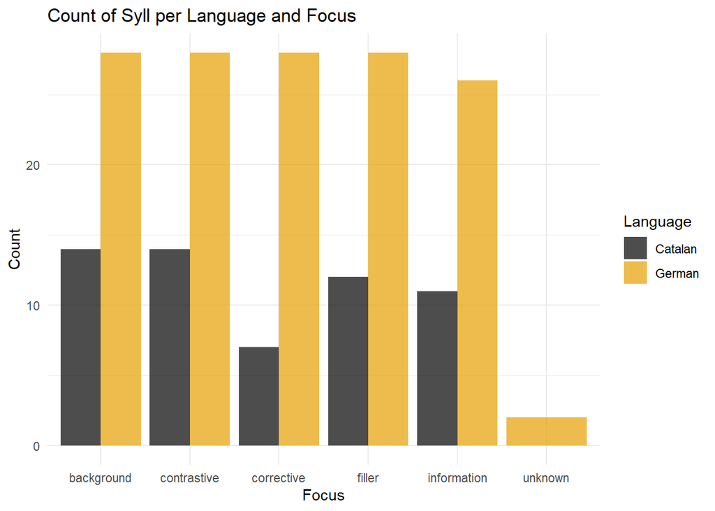

```r
## Count
ggplot(syll_per_foc, aes(x = Focus, y = Count, fill = Language)) +
  geom_bar(stat = "identity", position = "dodge", alpha = 0.7) +
  labs(title = "Count of Syll per Language and Focus",
       x = "Focus", y = "Count") +
  scale_fill_manual(values = colorBlindBlack8) +
  theme_minimal()
```

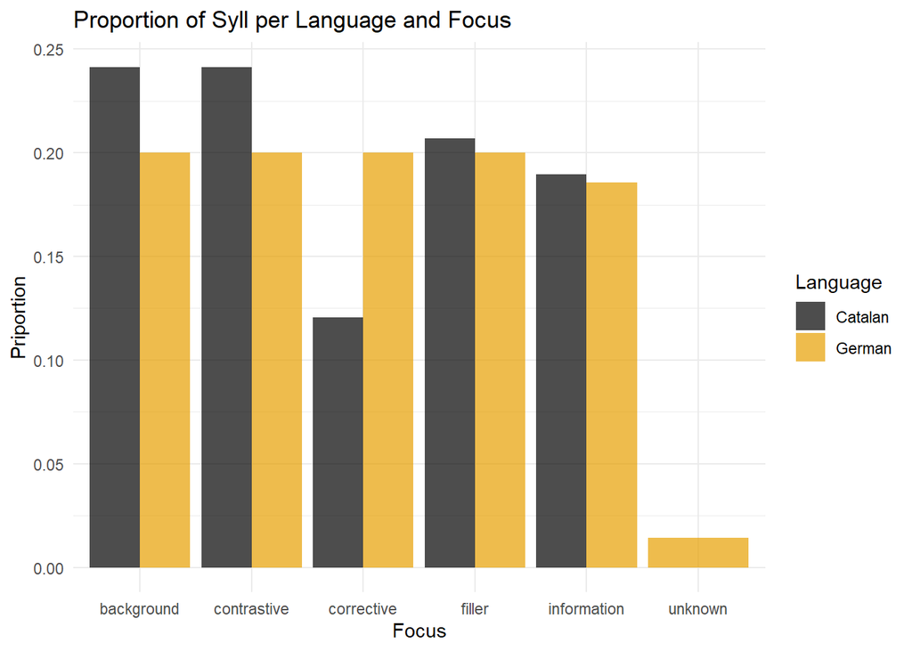

```r
## Proportion
ggplot(syll_per_foc, aes(x = Focus, y = Proportion, fill = Language)) +
  geom_bar(stat = "identity", position = "dodge", alpha = 0.7) +
  labs(title = "Proportion of Syll per Language and Focus",
       x = "Focus", y = "Priportion") +
  scale_fill_manual(values = colorBlindBlack8) +
  theme_minimal()
```

And how are they distributed across perceived prosodic prominence ratings?

```r
syll_per_pros <-
  df %>%
  filter(!(Syll %in% c("pre", "post", "", "post_pre", "disfluency", "<p>"))) %>%
  group_by(Language, Prosodic_Prom) %>%
  summarize(Count = n()) %>%
  mutate(Proportion = Count / sum(Count))
syll_per_pros
```

| Language | Prosodic_Prom | Count | Proportion |
| --- | --- | --- | --- |
| Catalan | 1 | 14 | 0.24137931 |
| Catalan | 2 | 33 | 0.56896552 |
| Catalan | 3 | 11 | 0.18965517 |
| German | 0 | 3 | 0.02142857 |
| German | 1 | 41 | 0.29285714 |
| German | 2 | 82 | 0.58571429 |
| German | 3 | 9 | 0.06428571 |
| German | NA | 5 | 0.03571429 |

```r
# Identify NA
df_targets %>%
  filter(Language == "German", is.na(Prosodic_Prom)) %>%
  select(File, Syll)
```

| Syll_num | File | Syll |
| --- | --- | --- |
| 7 | G01_T_03_I | ʃtɪft |
| 2 | G01_T_06_F | liː |
| 6 | G01_T_06_F | dra:t |
| 2 | G01_T_31_B | flø |
| 6 | G01_T_31_B | ʁɑːʃ |

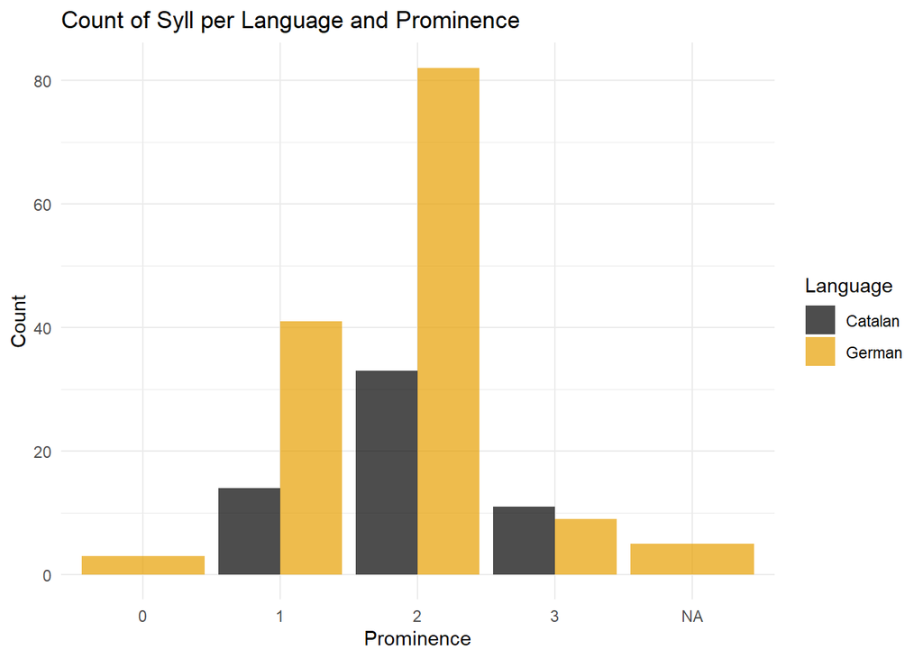

```r
## Count
ggplot(syll_per_pros, aes(x = Prosodic_Prom, y = Count, fill = Language)) +
  geom_bar(stat = "identity", position = "dodge", alpha = 0.7) +
  labs(title = "Count of Syll per Language and Prominence",
       x = "Prominence", y = "Count") +
  scale_fill_manual(values = colorBlindBlack8) +
  theme_minimal()
```

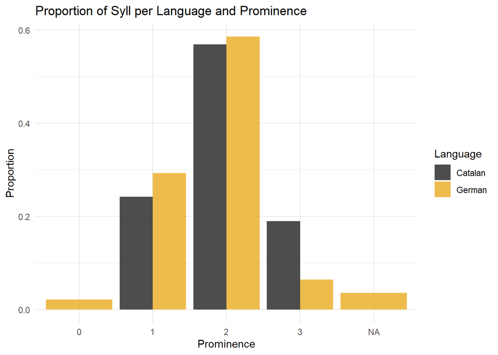

```r
## Proportion
ggplot(syll_per_pros, aes(x = Prosodic_Prom, y = Proportion, fill = Language)) +
  geom_bar(stat = "identity", position = "dodge", alpha = 0.7) +
  labs(title = "Proportion of Syll per Language and Prominence",
       x = "Prominence", y = "Proportion") +
  scale_fill_manual(values = colorBlindBlack8) +
  theme_minimal()
```

What is the average duration of the different prosodic prominence ratings in Catalan vs in German?

```r
df %>%
  filter(!(Syll %in% c("pre", "post", "", "post_pre", "disfluency", "<p>"))) %>%
  group_by(Language, Prosodic_Prom) %>%
  summarize(Average_Duration = mean(duration, na.rm = TRUE))
```

| Language | Prosodic_Prom | Average_Duration |
| --- | --- | --- |
| Catalan | 1 | 145.0000 |
| Catalan | 2 | 223.0303 |
| Catalan | 3 | 245.4545 |
| German | 0 | 256.6667 |
| German | 1 | 223.6585 |
| German | 2 | 287.0732 |
| German | 3 | 361.1111 |
| German | NA | 464.0000 |

Let’s plot it.

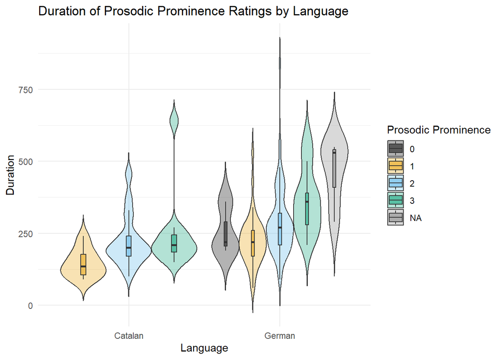

```r
ggplot(df_targets, aes(x = Language, y = duration, fill = Prosodic_Prom)) +
  geom_violin(scale = "width", trim = FALSE, alpha = 0.3) +
  geom_boxplot(width = 0.1, outlier.shape = NA, position = position_dodge(width = 0.9), alpha = 0.5) +
  labs(
    title = "Duration of Prosodic Prominence Ratings by Language",
    x = "Language",
    y = "Duration",
    fill = "Prosodic Prominence"
  ) +
  scale_fill_manual(values = colorBlindBlack8) +
  theme_minimal()
```

What is the average F0 of the different prosodic prominence ratings in Catalan vs in German?

```r
# Calculate z-scores for F0 within each combination of Language and Speaker
df_targets <- df_targets %>%
  group_by(Language, Participant) %>%
  mutate(F0_mean_z = scale(F0_mean))

# Calculate means for raw F0
df_targets %>%
  group_by(Language, Prosodic_Prom) %>%
  summarize(Average_F0 = mean(F0_mean, na.rm = TRUE))
```

| Language | Prosodic_Prom | Average_F0 |
| --- | --- | --- |
| Catalan | 1 | 225.1267 |
| Catalan | 2 | 229.4636 |
| Catalan | 3 | 224.4385 |
| German | 0 | 136.1932 |
| German | 1 | 150.6803 |
| German | 2 | 166.7098 |
| German | 3 | 141.7498 |
| German | NA | 100.6875 |

```r
# Calculate means for z-scored F0
df_targets %>%
  group_by(Language, Prosodic_Prom) %>%
  summarize(Average_F0_z = mean(F0_mean_z, na.rm = TRUE))
```

| Language | Prosodic_Prom | Average_F0_z |
| --- | --- | --- |
| Catalan | 1 | -0.11118699 |
| Catalan | 2 | 0.07898465 |
| Catalan | 3 | -0.14136106 |
| German | 0 | -1.03500304 |
| German | 1 | -0.19578722 |
| German | 2 | 0.09692625 |
| German | 3 | 0.51456097 |
| German | NA | -1.05598058 |

Let’s plot it.

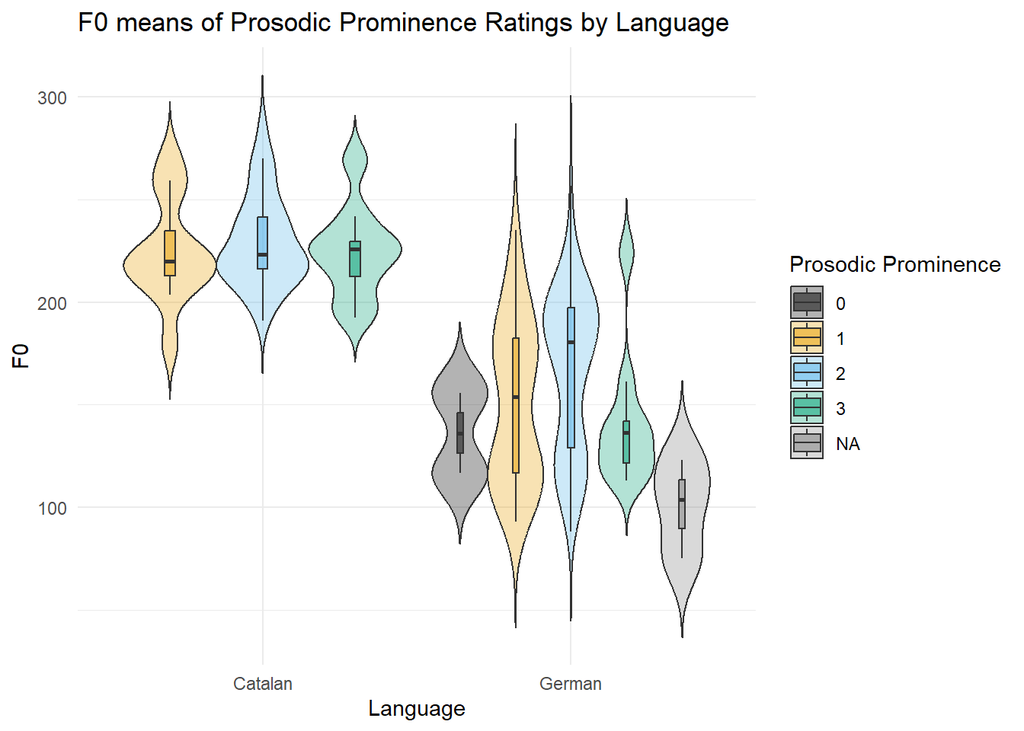

```r
## Raw F0
ggplot(df_targets, aes(x = Language, y = F0_mean, fill = Prosodic_Prom)) +
  geom_violin(scale = "width", trim = FALSE, alpha = 0.3) +
  geom_boxplot(width = 0.1, outlier.shape = NA, position = position_dodge(width = 0.9), alpha = 0.5) +
  labs(
    title = "F0 means of Prosodic Prominence Ratings by Language",
    x = "Language",
    y = "F0",
    fill = "Prosodic Prominence"
  ) +
  scale_fill_manual(values = colorBlindBlack8) +
  theme_minimal()
```

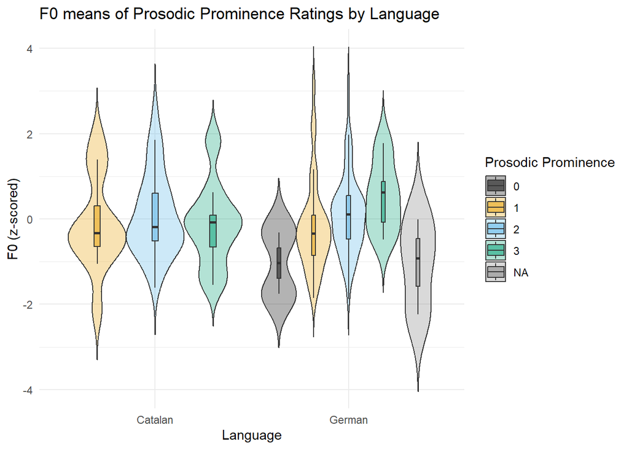

```r
## z-scored F0
ggplot(df_targets, aes(x = Language, y = F0_mean_z, fill = Prosodic_Prom)) +
  geom_violin(scale = "width", trim = FALSE, alpha = 0.3) +
  geom_boxplot(width = 0.1, outlier.shape = NA, position = position_dodge(width = 0.9), alpha = 0.5) +
  labs(
    title = "F0 means of Prosodic Prominence Ratings by Language",
    x = "Language",
    y = "F0 (z-scored)",
    fill = "Prosodic Prominence"
  ) +
  scale_fill_manual(values = colorBlindBlack8) +
  theme_minimal()
```

What is the average amplitude envelope of the different prosodic prominence ratings in Catalan vs in German?

```r
# Calculate z-scores for F0 within each combination of Language and Speaker
df_targets <- df_targets %>%
  group_by(Language, Participant) %>%
  mutate(env_mean_z = scale(env_mean))

# Calculate means for raw F0
df_targets %>%
  group_by(Language, Prosodic_Prom) %>%
  summarize(Average_env = mean(env_mean, na.rm = TRUE))
```

| Language | Prosodic_Prom | Average_env |
| --- | --- | --- |
| Catalan | 1 | 0.13724901 |
| Catalan | 2 | 0.15476055 |
| Catalan | 3 | 0.17004303 |
| German | 0 | 0.01604189 |
| German | 1 | 0.03960296 |
| German | 2 | 0.04084088 |
| German | 3 | 0.06166830 |
| German | NA | 0.02182814 |

```r
# Calculate means for z-scored F0
df_targets %>%
  group_by(Language, Prosodic_Prom) %>%
  summarize(Average_env_z = mean(env_mean_z, na.rm = TRUE))
```

| Language | Prosodic_Prom | Average_env_z |
| --- | --- | --- |
| Catalan | 1 | -0.38470263 |
| Catalan | 2 | 0.03158163 |
| Catalan | 3 | 0.39487663 |
| German | 0 | -1.24474173 |
| German | 1 | -0.08526327 |
| German | 2 | 0.05160918 |
| German | 3 | 0.87494180 |
| German | NA | -0.97528197 |

Let’s plot it.

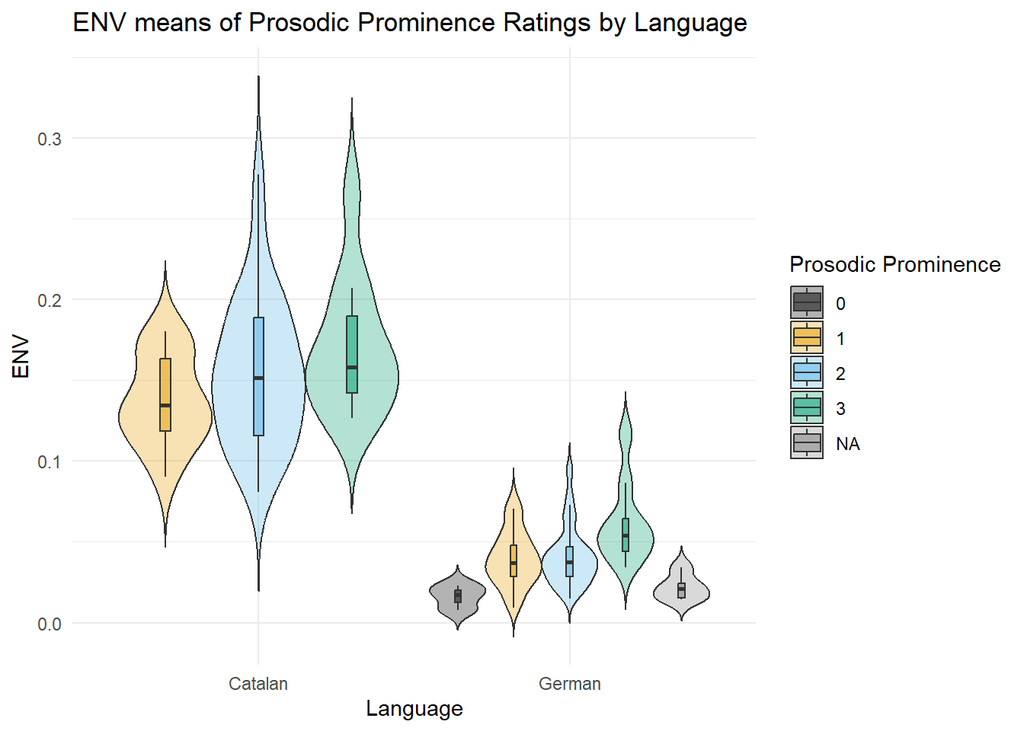

```r
## Raw env
ggplot(df_targets, aes(x = Language, y = env_mean, fill = Prosodic_Prom)) +
  geom_violin(scale = "width", trim = FALSE, alpha = 0.3) +
  geom_boxplot(width = 0.1, outlier.shape = NA, position = position_dodge(width = 0.9), alpha = 0.5) +
  labs(
    title = "ENV means of Prosodic Prominence Ratings by Language",
    x = "Language",
    y = "ENV",
    fill = "Prosodic Prominence"
  ) +
  scale_fill_manual(values = colorBlindBlack8) +
  theme_minimal()
```

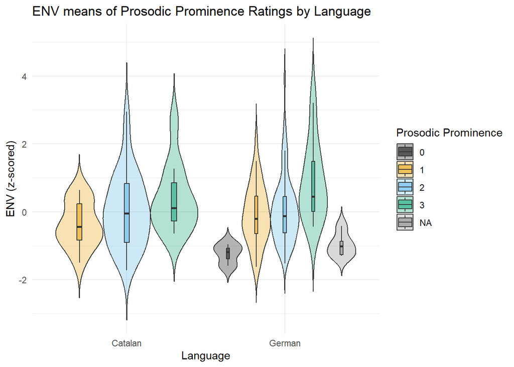

```r
## z-scored env
ggplot(df_targets, aes(x = Language, y = env_mean_z, fill = Prosodic_Prom)) +
  geom_violin(scale = "width", trim = FALSE, alpha = 0.3) +
  geom_boxplot(width = 0.1, outlier.shape = NA, position = position_dodge(width = 0.9), alpha = 0.5) +
  labs(
    title = "ENV means of Prosodic Prominence Ratings by Language",
    x = "Language",
    y = "ENV (z-scored)",
    fill = "Prosodic Prominence"
  ) +
  scale_fill_manual(values = colorBlindBlack8) +
  theme_minimal()
```

Try looking at pre- and post-tonic.

```r
df %>%
  arrange(Syll_num) %>%
  group_by(Syll) %>%
  mutate(
    prev_duration = case_when(
      Syll %in% c("pre", "post_pre") ~ lag(duration),
      TRUE ~ lag(duration, 2)
    ),
    next_duration = case_when(
      Syll %in% c("post", "post_pre") ~ lead(duration),
      TRUE ~ lead(duration, 2)
    )
  ) %>%
  summarize(
    avg_prev_duration = mean(prev_duration, na.rm = TRUE),
    avg_curr_duration = mean(duration),
    avg_next_duration = mean(next_duration, na.rm = TRUE)
  ) %>%
  ungroup()
```

| Syll | avg_prev_duration | avg_curr_duration | avg_next_duration |
| --- | --- | --- | --- |
|  | 304.6154 | 288.0000 | 268.4615 |
| a | NaN | 90.0000 | NaN |
| aʊ | NaN | 260.0000 | NaN |
| aʊ̯ | NaN | 120.0000 | NaN |
| baːs | NaN | 310.0000 | NaN |
| be | 130.0000 | 186.6667 | 180.0000 |
| beː | NaN | 180.0000 | NaN |
| blu | NaN | 280.0000 | NaN |
| bluː | NaN | 480.0000 | NaN |
| bo | NaN | 100.0000 | NaN |

[output cut: 89 more lines]

Ananthakrishnan, Sankaranarayanan, and Shrikanth S. Narayanan. 2008. “Automatic Prosodic Event Detection Using Acoustic, Lexical, and Syntactic Evidence.” *IEEE Transactions on Audio, Speech, and Language Processing* 16 (1): 216–28. https://doi.org/10.1109/tasl.2007.907570.

Breen, Mara, Laura C. Dilley, John Kraemer, and Edward Gibson,. 2012. “Inter-Transcriber Reliability for Two Systems of Prosodic Annotation: ToBI (Tones and Break Indices) and RaP (Rhythm and Pitch).” *Corpus Linguistics and Linguistic Theory* 8 (2): 277–312. https://doi.org/10.1515/cllt-2012-0011.

Cole, Jennifer, José I. Hualde, Caroline L. Smith, Christopher Eager, Timothy Mahrt, and Ricardo Napoleão de Souza. 2019. “Sound, Structure and Meaning: The Bases of Prominence Ratings in English, French and Spanish.” *Journal of Phonetics* 75 (July): 113–47. https://doi.org/10.1016/j.wocn.2019.05.002.

Krahmer, Emiel, and Marc Swerts. 2007. “The Effects of Visual Beats on Prosodic Prominence: Acoustic Analyses, Auditory Perception and Visual Perception.” *Journal of Memory and Language* 57 (3): 396–414. https://doi.org/10.1016/j.jml.2007.06.005.

Krifka, Manfred. 2008. “Basic Notions of Information Structure.” *Acta Linguistica Hungarica* 55 (3-4): 243–76. https://doi.org/10.1556/aling.55.2008.3-4.2.

Kügler, Frank, Stefan Baumann, Bistra Andreeva, Bettina Braun, Martine Grice, Jana Neitsch, Oliver Niebuhr, et al. 2019. “International Congress of Phonetic Sciences (ICPhS 2019).” In, 1297–1301. Melbourne, Australia.

Kügler, Frank, Stefan Baumann, and Christine T. Röhr. 2022. “Deutsche Intonation, Modellierung und Annotation.” In, edited by Cordula Schwarze and Sven Grawunder, 23–54. Tübingen: Narr Francke Attempto Verlag.

Kügler, Frank, Bernadett Smolibocki, Denis Arnold, Stefan Baumann, Bettina Braun, Martine Grice, Stefanie Jannedy, Jan Michalsky, Oliver Niebuhr, and Jörg Peters. 2015. “International Congress of Phonetic Sciences (ICPhS 2015).” In, 317–20. Glasgow, Scotland, UK. https://kops.uni-konstanz.de/handle/123456789/32841.

Rosenberg, Andrew. 2010. “AutoBI - a Tool for Automatic toBI Annotation.” *Interspeech 2010*, September. https://doi.org/10.21437/interspeech.2010-71.

Silverman, Kim, Mary Beckman, John Pitrelli, Mori Ostendorf, Colin Wightman, Patti Price, Janet Pierrehumbert, and Julia Hirschberg. 1992. “TOBI: A Standard for Labeling English Prosody.” *2nd International Conference on Spoken Language Processing (ICSLP 1992)*, October. https://doi.org/10.21437/icslp.1992-260.